# **6. Advanced Visualizations: Shot Maps**

## Question 1

The figure has been created with the use of ipywidgets and plotly. Since the dropdown is done through ipywidgets we can only export the image to html file.

## Question 2

The plots shows the concentration of how often the team shoots compared to the league team average in the same season.

- The regions which are in 'red' are where more than the league average shots are taken.
- The regions which are in 'blue' are where the less than the league average shits are taken.
- The regions which are in 'white' are where the same as the league average shots are taken or they didn't take any shots from there.

Usually we can see that most of the shots are taken near the goal area. But we can also see some long shots taken from near the center line.

## Question 3

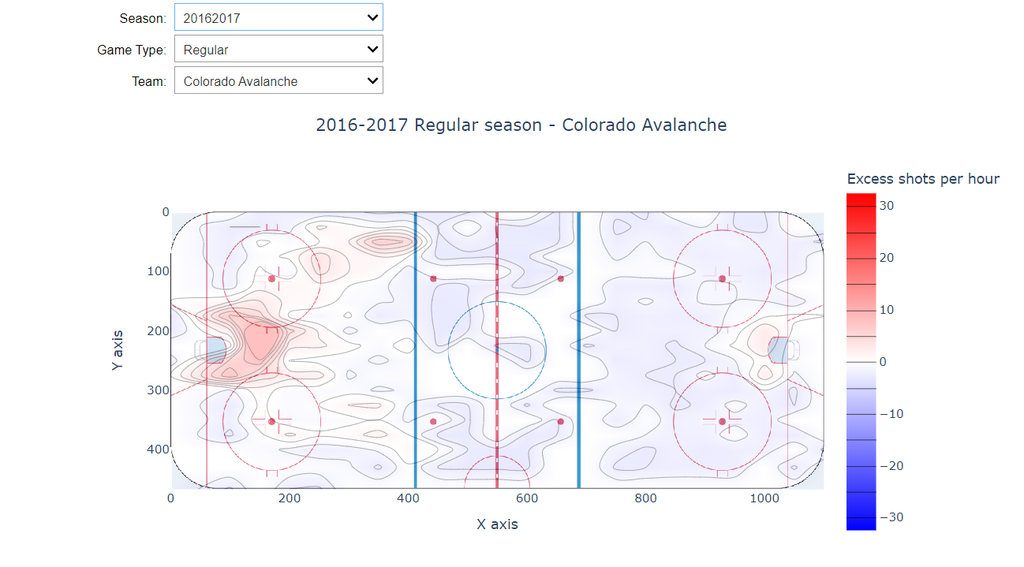

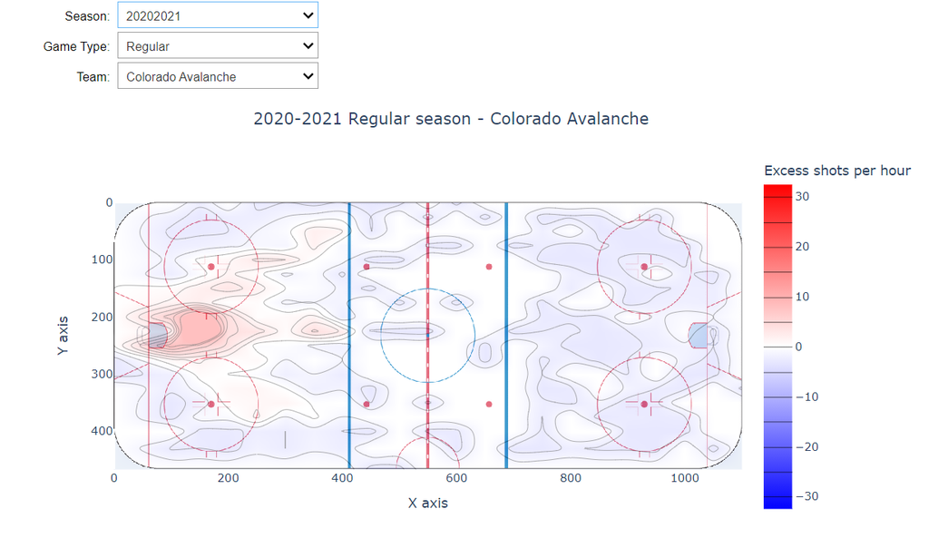

As per the plot we see that in season 2016-2017 Colorado Avalanche offence was not so strong as most shots are located in multiple places and some are far from goal which can lead to being blocked most of the times.

But in season 2020-2021 we see that most if the shots are near the goal which tells us the team has improved a lot in offence and the standings also proves the same. In 2016-2017 the team had 3 losses but in 2020-2021 they have 5 consecutives wins. The above plots tells how significantly they have improved in the last 4 years.

## Question 4

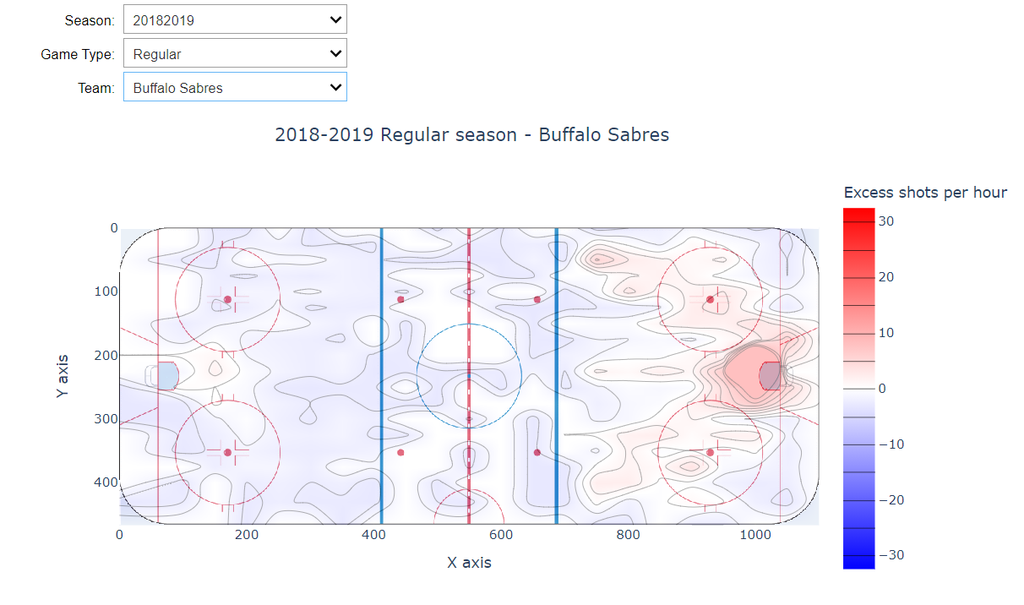

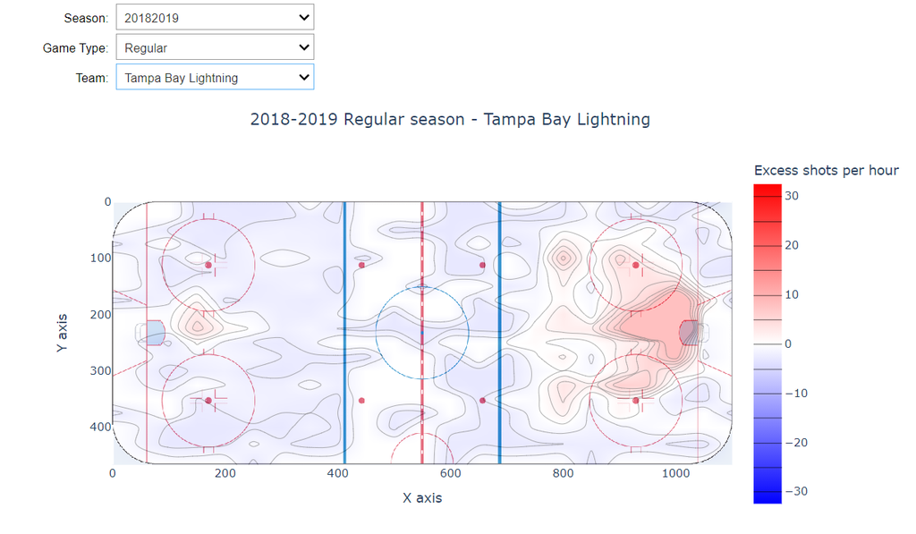

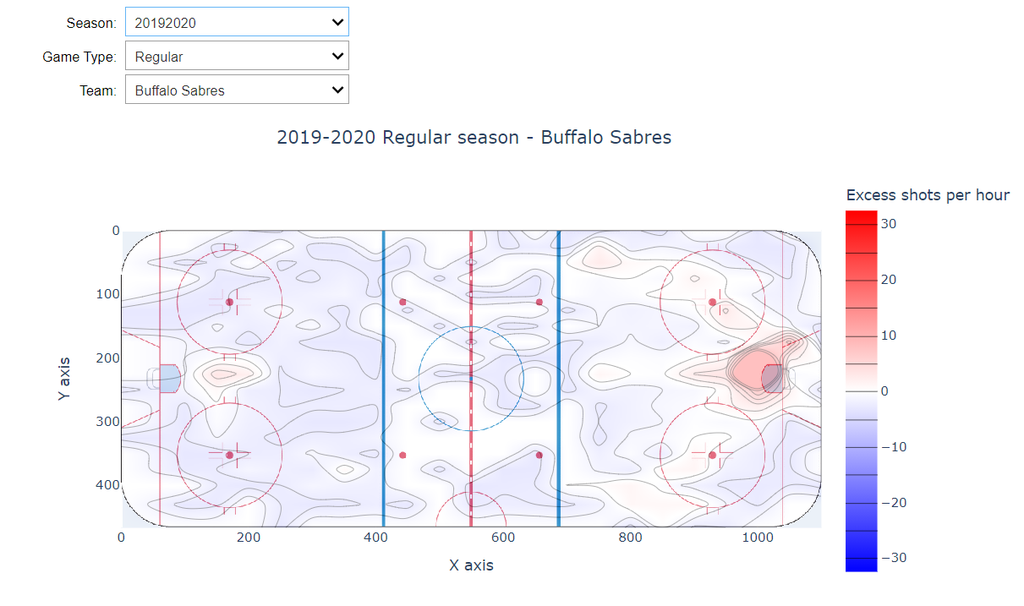

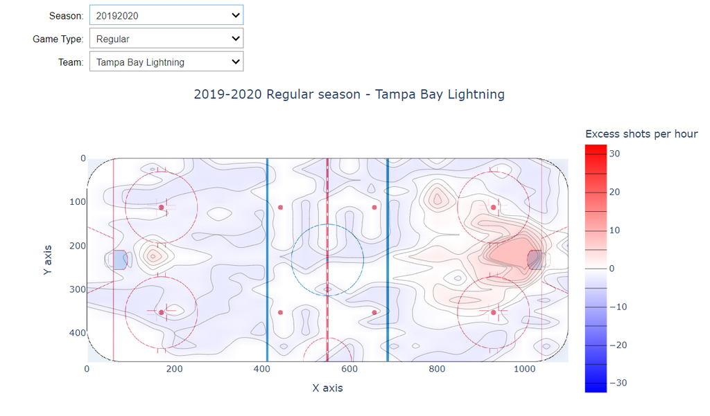

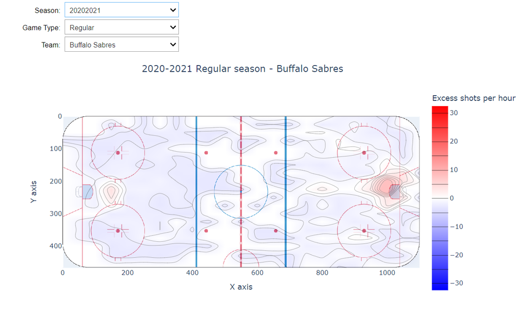

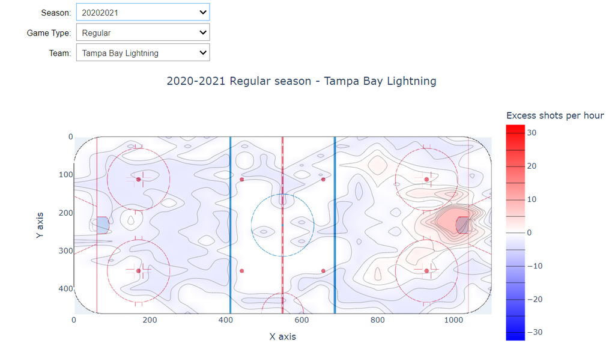

In 2018-19 season we can see that both the teams are good in offence but Tampa Bay Lightning is more number of shots near goal compared to Buffalo Sabers. Both had equally good standings as well in this season.

Similarly in 2019-20 season the shots taken by Tampa Bay Lightning is more compared to Buffalo Sabers. Not only the shots are more the shots are taken from multiple places near offence area which tells us that the defense of Buffalo Sabers has weaker defense compared to Tampa Bay Lightning. We can also see that standings of Tampa Bay which was way above than Buffalo Sabers.

Now in 2020-21 season like the previous seasons the number of shots taken by Tampa Bay Lightning is more than that of Buffalo Sabers. Also most of the shots are taken in offensive zone. This does prove that Tampa Bay lightning is much better as a team and have a better offence than Buffalo Sabers.

As per standings we do notice that the Tampa Bay Lightning was always ahead of Buffalo Sabers but in season 2020-21 the difference is significantly more than previous years.